# dec_trees

```python
import numpy as np
import pandas as pd
import matplotlib.pyplot as plt
import seaborn as sns

sns.set(style='whitegrid', font_scale=1.5, palette='Set2')
%matplotlib inline
```

```python
import warnings
import graphviz
from sklearn import datasets
from sklearn.metrics import accuracy_score, mean_squared_error
from sklearn.tree import DecisionTreeClassifier, DecisionTreeRegressor, export_graphviz
from sklearn.ensemble import RandomForestClassifier, RandomForestRegressor
from sklearn.model_selection import train_test_split
from sklearn.preprocessing import OneHotEncoder
from sklearn import metrics

warnings.filterwarnings("ignore")
```

```python
data = pd.read_csv('day.csv')
new_data = data[['season', 'mnth', 'holiday', 'weekday', 'workingday', 'temp', 'atemp', 'hum', 'windspeed', 'cnt']]
new_data.head()
```

|  | season | mnth | holiday | weekday | workingday | temp | atemp | hum | windspeed | cnt |
| --- | --- | --- | --- | --- | --- | --- | --- | --- | --- | --- |
| 0 | 1 | 1 | 0 | 6 | 0 | 0.344167 | 0.363625 | 0.805833 | 0.160446 | 985 |
| 1 | 1 | 1 | 0 | 0 | 0 | 0.363478 | 0.353739 | 0.696087 | 0.248539 | 801 |
| 2 | 1 | 1 | 0 | 1 | 1 | 0.196364 | 0.189405 | 0.437273 | 0.248309 | 1349 |
| 3 | 1 | 1 | 0 | 2 | 1 | 0.200000 | 0.212122 | 0.590435 | 0.160296 | 1562 |
| 4 | 1 | 1 | 0 | 3 | 1 | 0.226957 | 0.229270 | 0.436957 | 0.186900 | 1600 |

```python
train, rem = train_test_split(new_data, train_size=0.6)
valid, test = train_test_split(rem, test_size=0.5)
```

Выполните необходимые преобразования признаков

```python
categorial_features = ['season','mnth', 'holiday', 'weekday', 'workingday']  # категориальные признаки
real_features = ['temp', 'atemp', 'hum', 'windspeed']  # вещественные признаки
target_feature = 'cnt'  # целевой признак
```

```python
encoder = OneHotEncoder(sparse=False)
train_cat = encoder.fit_transform(train[categorial_features])
valid_cat = encoder.fit_transform(valid[categorial_features])
test_cat = encoder.fit_transform(test[categorial_features])
```

```python
X_train = np.hstack([train[real_features], train_cat])
X_valid = np.hstack([valid[real_features], valid_cat])
X_test = np.hstack([test[real_features], test_cat])
```

```python
y_train = train[target_feature]
y_valid = valid[target_feature]
y_test = test[target_feature]
```

```python
encoder.categories_
```

```
[array([1, 2, 3, 4]),
 array([ 1,  2,  3,  4,  5,  6,  7,  8,  9, 10, 11, 12]),
 array([0, 1]),
 array([0, 1, 2, 3, 4, 5, 6]),
 array([0, 1])]
```

```python
new_categorial_features = ['весна', 'лето', 'осень', 'зима', 'Январь', 'Февраль', 'Март', 'Апрель', 'Май',
                           'Июнь', 'Июль', 'Август', 'Сентябрь', 'Октябрь', 'Ноябрь', 'Декабрь', 'каникулы', 'не каникулы',
                          'Понедельник', 'Вторник', 'Среда', 'Четверг', 'Пятница', 'Суббота', 'Воскресенье', 'выходной', 'рабочий']
```

Обучите решающее дерево глубины 3 и визуализируйте его

```python
estimator_for_visualisation = DecisionTreeRegressor(max_depth=3)
estimator_for_visualisation.fit(X_train, y_train)
```

```
DecisionTreeRegressor(max_depth=3)
```

```python
def get_graphviz_graph(decision_tree_regressor):

    dot_data = export_graphviz(
        decision_tree_regressor, out_file=None,
        feature_names=[*real_features, *new_categorial_features], class_names='cnt',
        filled=True, rounded=True, special_characters=True
    )
    return graphviz.Source(dot_data)
```

```python
graph = get_graphviz_graph(estimator_for_visualisation)
graph
```

[figure not shown]

Подберите оптимальное значение максимальной глубины дерева. Для этого обучите решающие деревья с выставленным значением соответствующего гиперпараметра и посчитайте точность предсказаний каждого из них на валидационной выборке. Постройте соответствующий график.

```python
metric_for_depth = []
for max_level in [1, 2, 3, 5, 10, 20, 40]:
    estimator = DecisionTreeRegressor(max_depth=max_level)
    estimator.fit(X_train, y_train)
    metric_for_depth.append(mean_squared_error(estimator.predict(X_valid), y_valid))
```

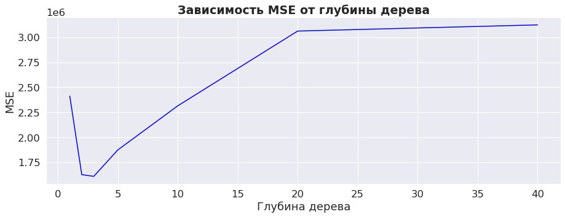

```python
with sns.axes_style('darkgrid'):
    fig, ax = plt.subplots(figsize=(15, 5))
    ax.plot([1, 2, 3, 5, 10, 20, 40], metric_for_depth, color="blue")
    ax.set_xlabel('Глубина дерева')
    ax.set_ylabel("MSE")
    ax.set_title("Зависимость MSE от глубины дерева", fontsize = 19, fontweight = "bold")
    plt.show()
```

```python
metric_for_leaf = []
for min_leaf in [1, 2, 3, 5, 7, 10, 15, 20, 40]:
    estimator = DecisionTreeRegressor(min_samples_leaf = min_leaf, max_depth=5)
    estimator.fit(X_train, y_train)
    metric_for_leaf.append(mean_squared_error(estimator.predict(X_valid), y_valid))
```

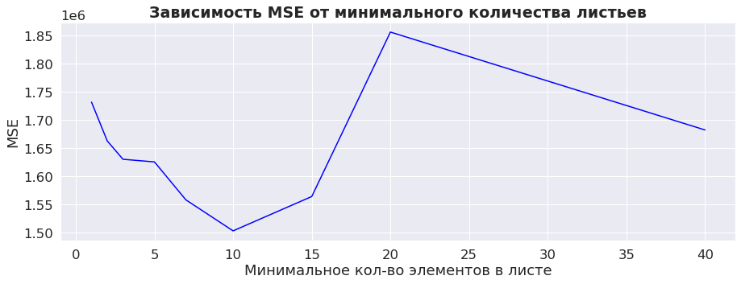

```python
with sns.axes_style('darkgrid'):
    fig2, ax2 = plt.subplots(figsize=(15, 5))
    ax2.plot([1, 2, 3, 5, 7, 10, 15, 20, 40], metric_for_leaf, color="blue")
    ax2.set_xlabel('Минимальное кол-во элементов в листе')
    ax2.set_ylabel("MSE")
    ax2.set_title("Зависимость MSE от минимального количества листьев", fontsize = 19, fontweight = "bold")
    plt.show()
```

```python
def mean_absolute_percentage_error(y_true, y_pred):
    return 100 * (np.abs(y_true - y_pred) / y_true).mean()
```

```python
model = DecisionTreeRegressor(max_depth = 5, min_samples_leaf = 20)
model.fit(X_train, y_train)
test_predict = model.predict(X_test)
```

```python
print(metrics.mean_squared_error(test[target_feature], test_predict) ** 0.5)
```

```
1296.6382250005977
```

MAE

```python
print(metrics.mean_absolute_error(test[target_feature], test_predict))
```

```
1065.787332142737
```

MAPE

```python
print(mean_absolute_percentage_error(test[target_feature], test_predict))
```

```
27.859078724689805
```

```python
graph_opt = get_graphviz_graph(model)
graph_opt
```

[figure not shown]

Решающее дерево позволяет оценить *важность признаков* — некоторая величина, зависящая от того

- насколько часто тот или иной признак использовался при разбиении листа,
- и насколько сильно при этом изменился критерий информативности.